# NBA Player Salary Prediction Model

Tyler Guo, Keshav Lodha, Zen Yoshida, Felix Yang

2024-10-03

Introduction and Background

The NBA, or National Basketball Association, is regarded as the premier basketball league in the world, meaning it draws in both the top basketball talent and most revenue. Each team in the NBA has the same operating budget for players, or salary cap.

Statistical tracking of every player has been largely in effect since 1996. There are various statistics based on which the salary of a player is decided. Every team pays their respective players according to what the team believes they are worth. There are many cases in which an under-performing player is paid much more than better performing players on the team. Thus, our motivation in this data analysis project is to determine which player statistics have the most impact on their salary, allowing us to discover which metrics matter most to NBA teams when they are paying players.

Then we wish to build a predictive model off of these individual player statistics to predict a player’s salary based off of their on-court statistics. This will help identify if any player is being over or under paid and on what basis (statistical measurement) we are able to come to this conclusion.

Introduction to Dataset

The dataset we will be using for this project is from the Data World website, given here by this url link:

https://data.world/nolanoreilly495/nba-data-with-salaries-1996-2017/workspace/file?filename=NBA+Data+With+Salaries.xlsx.

Data Description: Total number of variables: 51 Number of categorical variables: 3 (Player Name, Position, & Team) Number of Continuous/Numeric variables: 48 (Salary, Age, etc.) Total Number of rows: 12,377

The data set collects data from the 1996 season to the 2017 season, meaning it spans about two decades of the NBA. However, for the context of this project, we will only be using the most recent 6 years as our data set because inflation and salary cap negotiations have greatly increased the value of the average NBA contract in the last 20 years.

Our variable of interest is the Salary, as we hope to be able to estimate that value based off of the other statistics.

Exploratory Data Analysis

General Histogram

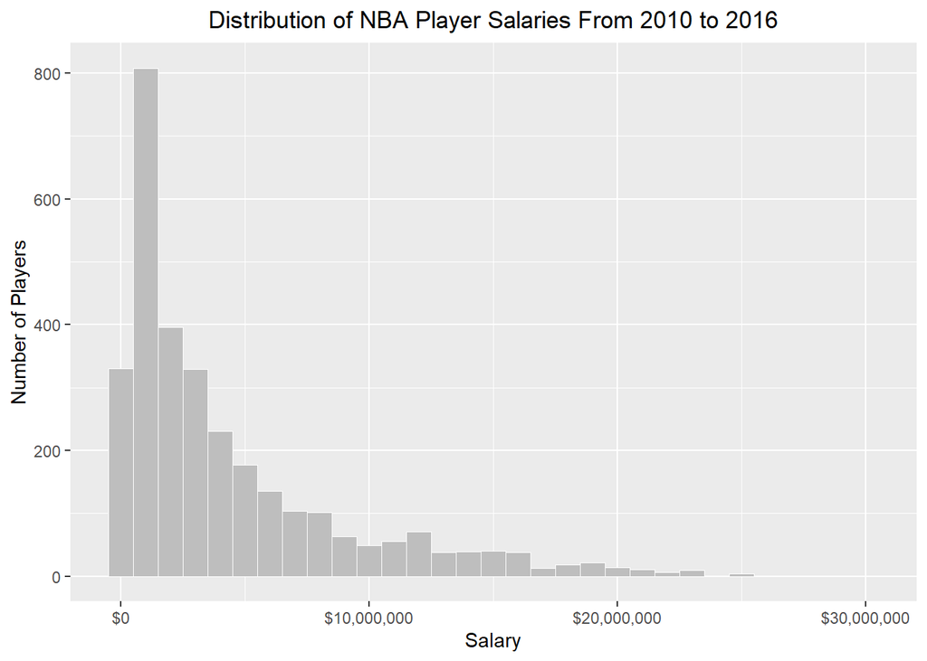

The histogram above gives us a good representation of the problem. The gross majority of players earn less than 5 million dollars a year, and only a select few earn more than 20 million dollars a year. Thus, the problem statement is explaining why certain players earn so much more than others. What do these players do on the court that makes them “worth” so much more money?

Categorical Variable Analysis

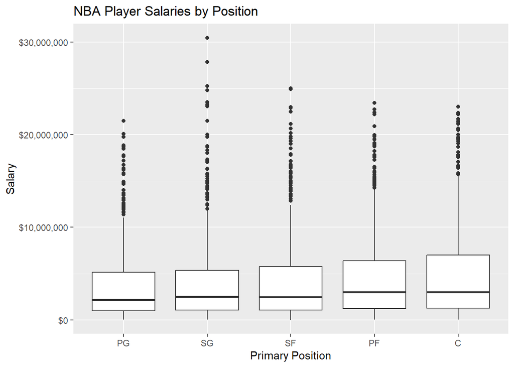

The plot above shows the salary boxplot for each position. This is the only analysis we will be doing with the player’s positions, as this is a categorical variable and we wish to only use continous variables in our prediction models. However, it should be noted that generally speaking, bigger players get paid more. This is because finding a capable 7 footer is much rarer than finding a capable 6 footer, thus taller players, on average, command larger salaries.

Correlation Heatmap

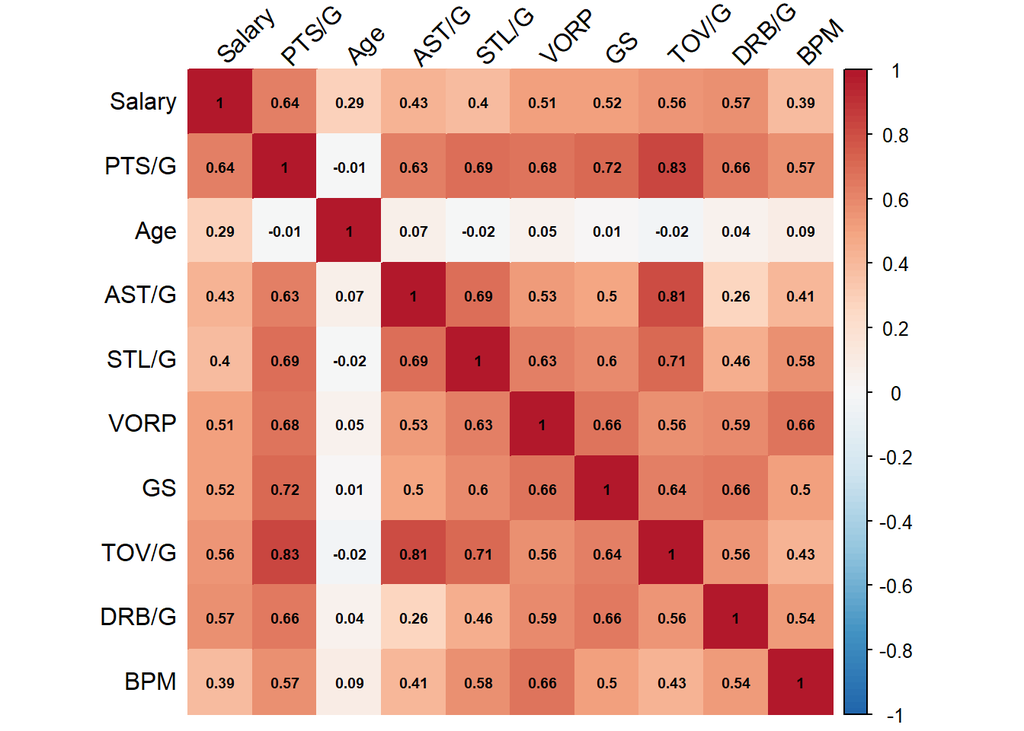

Above shows a correlation heatmap of the variables most correlated with Player Salary. Some logical conclusions can be easily drawn here, such as the high correlation between TOV/G (Turnovers Per Game) and PTS/G (Points Per Game), which makes sense as more points = more shots = more time with the ball = more chances for turning the ball over. Certain variables also seem to not have a lot of correlation with other variables, namely the Age variable.

Basic Data Table

|  | Salary_Group | PTS/G_mean | PTS/G_sd | Age_mean | Age_sd | AST/G_mean | AST/G_sd |
| --- | --- | --- | --- | --- | --- | --- | --- |
| 1 | $0 - $5e+06 | 6.451576 | 4.3456176 | 25.86897 | 4.2742927 | 1.403651 | 1.381731 |
| 2 | $5e+06 - $1e+07 | 11.124920 | 5.1504563 | 28.05952 | 3.7171930 | 2.537532 | 2.029266 |
| 3 | $1e+07 - $1.5e+07 | 14.233115 | 5.3564238 | 28.33333 | 3.2746173 | 3.402629 | 2.578440 |
| 4 | $1.5e+07 - $2e+07 | 18.283935 | 5.5407316 | 28.73276 | 3.1906324 | 3.473878 | 2.296901 |
| 5 | $2e+07 - $2.5e+07 | 18.449896 | 5.4533051 | 31.45161 | 2.5276960 | 3.654710 | 2.393158 |
| 6 | $2.5e+07 - $3e+07 | 27.604111 | 0.3648071 | 33.50000 | 0.7071068 | 5.282272 | 1.033151 |

Rounding Salary Values to the Nearest Million

Rounding the Salary Values to the nearest million will allow our prediction models to perform much better and provide more interpretable results for our data analysis

Methodology and Testing Results

Linear Regression Model: The first model that we will be using on our data set is the linear regression model. We choose this model because it is perhaps the most easily interpretable method due to its simplicity. Furthermore, this model is widely understood and can serve as a baseline for us to operate off of, allowing us to compare our findings using more complex models to the basic linear regression model.

```
## The Mean Squared Error For Linear Regression is: 10.90282
```

```
## The R squared Value for the Linear Regression Model is: 0.4962533
```

Linear Regression Summary

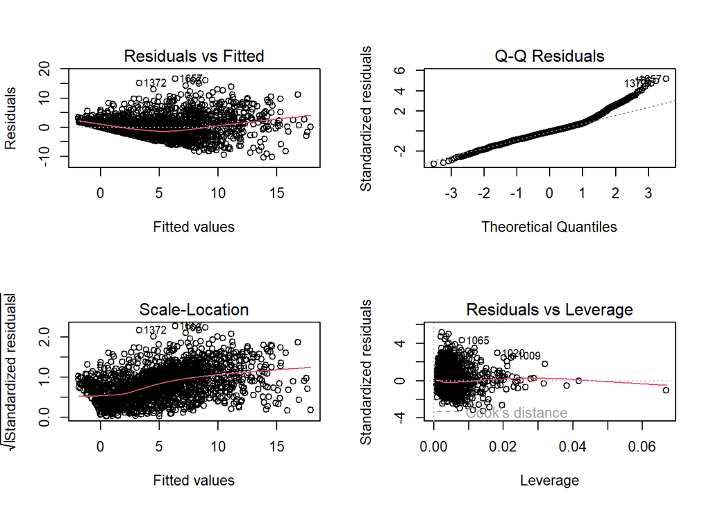

Ridge Regression: The second model we will be using is the ridge regression model. We choose this model because of its ability to handle multicollinearity. As seen in our exploratory data analysis, many of our predictor variables are correlated with each other, meaning that these independent variables are highly correlated, which might impact their coefficient estimates. Ridge Regression helps mitigate the impact of multicollinearity, allowing us to obtain more reliable coefficient estimates. Furthermore, ridge regression is robust against noisy data, or outliers, which in our case is extremely helpful.

```
## The Mean Squared Error for the Ridge Regression Model is: 10.83925
```

```
## The R squared value for the Ridge Regression Model is: 0.4975825
```

The Ridge Regression model gives us a R-squared value of 0.4975825 and a MSE of 10.83925. These results are similar to that of the linear regression model.

Ridge Regression Coeffecient Analysis

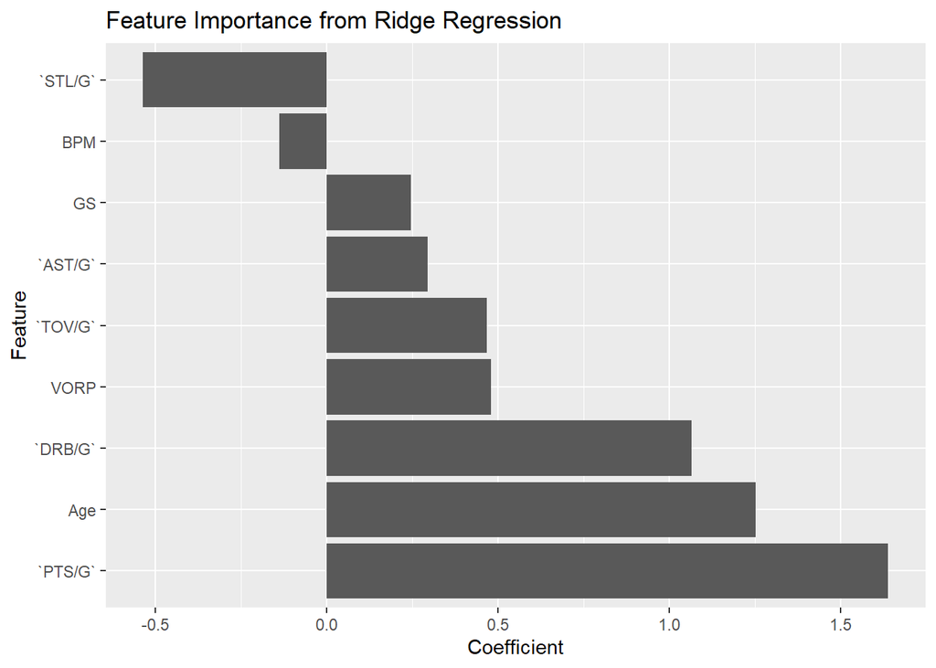

From the graph above, we can ascertain that the most influential predictor variables are `PTS/G`, `Age`, and `DRB/G`. Interestingly, the `STL/G` and `BPM` displays a negative associations with salaries for the Ridge Regression Model.